# 予備実験の解析結果

Rai Sato

# exp1: 繰り返し回数nの検討

$\Delta t$ 0, 45, 150の刺激を100回呈示して、これを基準とした繰り返し回数とnを減らした結果がどのように違うかを検討する。 今回はn=100の他にn=25, n=23, n=20, n=17の4種類を計算した。n=100以外のデータは実験結果から任意の5点をそれぞれ抽出してその平均値を表示している。 実験参加者は3人。 実験で得られたデータは階層的モデルによって個人差が表現されたベイズ信号検出理論(HSDT:下図参照)によってそれぞれのパラメータが推量されている。

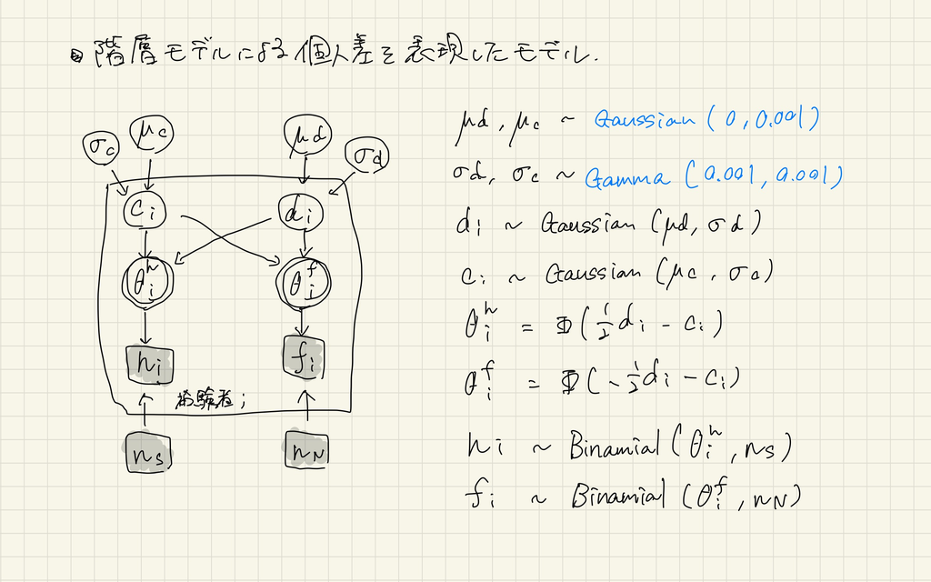

graphical model for HSDT

```
// Hierarchical Signal Detection Theory
data {
  int<lower=1> k;
  int<lower=0> h[k];
  int<lower=0> f[k];
  int<lower=0> s;
  int<lower=0> n;
}
parameters {
  vector[k] d;
  vector[k] c;
  real mud;
  real muc;
  real<lower=0> sigmad;
  real<lower=0> sigmac;
}

transformed parameters {
  real<lower=0,upper=1> thetah[k];
  real<lower=0,upper=1> thetaf[k];

  for(i in 1:k) {
    thetah[i] = Phi(d[i] / 2 - c[i]);
    thetaf[i] = Phi(-d[i] / 2 - c[i]);
  }
}
model {
  mud ~ normal(0, sqrt(1000));
  muc ~ normal(0, sqrt(1000));

  d ~ normal(mud, sigmad);
  c ~ normal(muc, sigmac);
  h ~ binomial(s, thetah);
  f ~ binomial(n, thetaf);
}
```

ベイズ用のコードはLee, Michael D., and Eric-Jan Wagenmakers. Bayesian cognitive modeling: A practical course. Cambridge university press, 2014.のJAGSコードをRstan用に書き換えた[神リポジトリ](https://github.com/stan-dev/example-models/tree/master/Bayesian_Cognitive_Modeling)より

## n=25の結果

mud, sigmadは全参加者のd(弁別力: discriminability)の平均と標準偏差を表していて、d1-3とd1-3_sdは各実験参加者のdにおける事後平均と事後標準偏差を表している。

|  | mud | sigmad | d1 | d2 | d3 | d1_sd | d2_sd | d3_sd |
| --- | --- | --- | --- | --- | --- | --- | --- | --- |
| n100_dt45 | 0.6516 | 2.967 | 0.6212 | 1.244 | 0.2789 | 0.2266 | 0.2113 | 0.3071 |
| n100_dt150 | 3.6729 | 5.519 | 2.6868 | 4.924 | 3.8664 | 0.2528 | 1.4144 | 0.3765 |
| n25_dt45 | 0.6458 | 3.330 | 0.7502 | 1.032 | 0.2115 | 0.4950 | 0.3902 | 0.5484 |
| n25_dt150 | 4.2234 | 5.609 | 3.2724 | 4.656 | 4.9707 | 0.5710 | 1.5413 | 1.4622 |

## n=23の結果

|  | mud | sigmad | d1 | d2 | d3 | d1_sd | d2_sd | d3_sd |
| --- | --- | --- | --- | --- | --- | --- | --- | --- |
| n100_dt45 | 0.6965 | 2.906 | 0.6175 | 1.244 | 0.2802 | 0.2236 | 0.2127 | 0.3079 |
| n100_dt150 | 3.7273 | 6.726 | 2.6902 | 4.912 | 3.8694 | 0.2555 | 1.4028 | 0.3749 |
| n23_dt45 | 0.6273 | 3.270 | 0.7182 | 1.023 | 0.1899 | 0.5065 | 0.4083 | 0.5622 |
| n23_dt150 | 4.5068 | 5.527 | 3.8791 | 4.869 | 5.2070 | 0.8052 | 1.5804 | 1.4855 |

## n=20の結果

|  | mud | sigmad | d1 | d2 | d3 | d1_sd | d2_sd | d3_sd |
| --- | --- | --- | --- | --- | --- | --- | --- | --- |
| n100_dt45 | 0.7618 | 2.797 | 0.6224 | 1.242 | 0.2824 | 0.2262 | 0.2147 | 0.3089 |
| n100_dt150 | 3.8706 | 5.334 | 2.6896 | 4.865 | 3.8658 | 0.2500 | 1.4157 | 0.3803 |
| n20_dt45 | 0.9681 | 4.946 | 1.8905 | 1.090 | 0.1914 | 2.1060 | 0.4357 | 0.5813 |
| n20_dt150 | 5.0500 | 7.422 | 5.4076 | 5.034 | 5.2534 | 2.2177 | 1.6136 | 1.5114 |

## n=17の結果

|  | mud | sigmad | d1 | d2 | d3 | d1_sd | d2_sd | d3_sd |
| --- | --- | --- | --- | --- | --- | --- | --- | --- |
| n100_dt45 | 0.6426 | 3.167 | 0.6192 | 1.245 | 0.2772 | 0.2279 | 0.2111 | 0.3042 |
| n100_dt150 | 3.7426 | 5.716 | 2.6879 | 4.921 | 3.8714 | 0.2541 | 1.4192 | 0.3770 |
| n17_dt45 | 0.7676 | 11.381 | 2.3122 | 1.222 | -1.2929 | 3.9755 | 0.5081 | 4.0459 |
| n17_dt150 | 5.8739 | 8.428 | 6.2469 | 5.332 | 7.0950 | 2.9568 | 1.7554 | 2.9542 |

## 結果の考察

n=25の時とn=23の時はぱっと見おおよそn=100と変わらない気がするが、n=20,n=17の時は大きく違う値が出ているところもある。 この感じからみるとn=23が良いのかなあと思われるが、どの値を目安に最終的にnを決めれば良いのかはちょっとわからない。(一つ手としては各dのsdがn=100と比べて極端に大きくなっていない[例えばsd≒1ぐらい]のところにするとかかなあ)

ちなみにn=20の場合の実験時間は$\Delta t = 11$ * $A = 3$ * $n=20$ で 01:28:00。 n=23の場合は01:41:12となる。(一試行あたりの回答時間を8秒として計算)

# exp2: $\Delta t$の検討

今までの実験結果から、

1. $\pm 150\rm{ms}$のときはほぼ全ての実験参加者は必ずずれていると答える。
2. $\Delta t$が大体$\pm60 \rm{ms}$から$\pm30 \rm{ms}$ぐらいのところに同時/非同時の分かれ目がくるだろう。

ということが（経験的に）わかったので、それらを加味して、$\Delta t$が$-150, -75, -60, -45, -30, 0, 30, 45, 60, 75, 150\rm{ms}$になるように実験パラメータを設定した。 今回の予備実験では、上の仮説があっているのかどうかをHSDTを使って検討する。

## 実験結果

|  | mud | sigmad | d1 | d2 | d3 | d1_sd | d2_sd | d3_sd |
| --- | --- | --- | --- | --- | --- | --- | --- | --- |
| -150 | 9.708871 | 18.30714 | 14.142178 | 6.36833916 | 13.685271 | 7.903179 | 1.9190782 | 7.406957 |
| -75 | 7.692389 | 21.95201 | 10.909131 | 2.70144948 | 14.900317 | 8.117240 | 0.5781962 | 8.470754 |
| -60 | 7.272084 | 24.62300 | 9.991897 | 1.36395489 | 15.176591 | 7.793055 | 0.4852373 | 8.307763 |
| -45 | 5.611882 | 18.76417 | 8.426634 | 0.69703693 | 10.217276 | 7.605603 | 0.5071131 | 7.522414 |
| -30 | 4.674222 | 18.64026 | 7.382897 | 0.02560099 | 9.337221 | 7.596110 | 0.5690129 | 7.636216 |
| 30 | 4.251227 | 15.14373 | 7.579611 | 0.72229068 | 6.944895 | 7.348710 | 0.5140753 | 7.315228 |
| 45 | 4.048291 | 15.43346 | 7.740254 | 0.33192186 | 6.551126 | 7.388592 | 0.5209686 | 7.428498 |
| 60 | 4.524176 | 13.93049 | 7.186325 | 1.16459707 | 7.131030 | 7.108798 | 0.4916409 | 7.262121 |
| 75 | 5.496220 | 16.33682 | 8.674164 | 1.29411183 | 9.005003 | 7.502689 | 0.4975044 | 7.394546 |
| 150 | 9.196369 | 18.48585 | 11.538302 | 6.27933976 | 14.310943 | 7.492959 | 1.8949435 | 8.276455 |

見てわかるように、d1とd3の$d \prime$が総じておかしい値になっている。これはおそらく、d1・d3とd2の個人差が大きすぎて、d1・d3の$d \prime$が良く出過ぎてしまっているためだと考えられる(sigmadがめちゃくちゃでかいので)。そこで、階層モデルを使わずに各実験参加者それぞれに対して、通常のベイズ信号検出理論(下図参照)を使った分析を行ってみることにした。

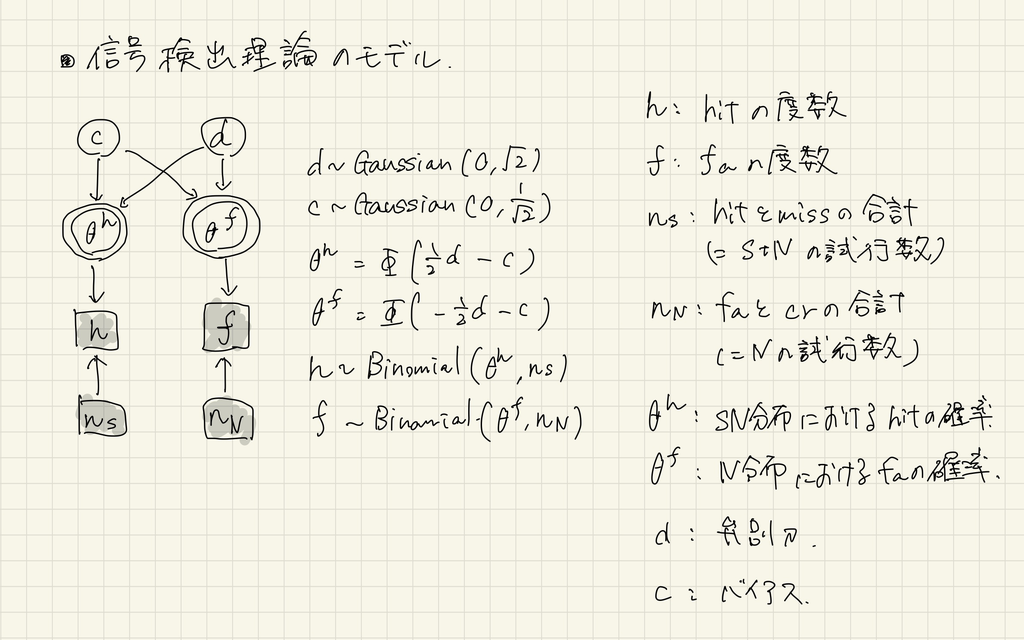

graphical model for SDT

```
// Signal Detection Theory
data {
  int<lower=1> k;
  int<lower=0> h[k];
  int<lower=0> f[k];
  int<lower=0> s[k];
  int<lower=0> n[k];
}
parameters {
  vector[k] d;
  vector[k] c;
}
transformed parameters {
  real<lower=0,upper=1> thetah[k];
  real<lower=0,upper=1> thetaf[k];

  // Reparameterization Using Equal-Variance Gaussian SDT
  for(i in 1:k) {
    thetah[i] = Phi(d[i] / 2 - c[i]);
    thetaf[i] = Phi(-d[i] / 2 - c[i]);
  }
}
model {
  // These Priors over Discriminability and Bias Correspond
  // to Uniform Priors over the Hit and False Alarm Rates
  d ~ normal(0, inv_sqrt(sqrt(2)));
  c ~ normal(0, inv_sqrt(1/sqrt(2)));

  // Observed counts
  h ~ binomial(s, thetah);
  f ~ binomial(n, thetaf);
}"
```

上と同じく[神リポジトリ](https://github.com/stan-dev/example-models/tree/master/Bayesian_Cognitive_Modeling)より

### 通常のベイズ信号検出理論を使った分析結果

|  | d1 | d1_sd | d2 | d2_sd | d3 | d3_sd |
| --- | --- | --- | --- | --- | --- | --- |
| -150 | 2.7267264 | 0.4982022 | 2.352786547 | 0.4755389 | 2.7278229 | 0.5011517 |
| -75 | 2.2182623 | 0.4725924 | 1.919784343 | 0.4220759 | 2.7275159 | 0.5020528 |
| -60 | 1.8921734 | 0.4708862 | 1.001259418 | 0.4020606 | 2.7289570 | 0.5045360 |
| -45 | 1.3541289 | 0.4980647 | 0.462922251 | 0.4193043 | 2.3523850 | 0.4739479 |
| -30 | 0.8094686 | 0.5473743 | 0.001198543 | 0.4538709 | 1.8948146 | 0.4712371 |
| 30 | 1.2620932 | 0.5010802 | 0.495453780 | 0.4230917 | 0.8059661 | 0.5443350 |
| 45 | 1.2636748 | 0.5010037 | 0.205857466 | 0.4412396 | 0.4228561 | 0.5987857 |
| 60 | 1.2580788 | 0.4986743 | 0.838725387 | 0.4073763 | 1.1651160 | 0.5085864 |
| 75 | 1.8974737 | 0.4725444 | 0.902248504 | 0.4058828 | 2.0995678 | 0.4734791 |
| 150 | 2.5133770 | 0.4845003 | 2.352913569 | 0.4748131 | 2.7277723 | 0.5024980 |

それなりにいい感じのデータが出たっぽい。d1・d3はおそらくこう言うaudio-tactileの実験が得意なので、$\pm45$から$30\rm{ms}$あたりに閾値がありそう。逆にd2は大体$\pm 75$から $60 \rm{ms}$にありそう。

## わかったこと

- 個人差が大きい時は、HSDT使うと結果がおかしくなる。

-> そもそもHSDTはかなり複雑なモデルなので、モデリング結果も不安定になりがち(後述)。結果を見てみて、sigmadが大きいようだったらとりあえず通常のSDTでそれぞれ結果を出してみて、その後の分析で個人差を加味したデータ出力をしたほうが良いかも。

- $\Delta t$の値はいい感じそう

-> 万が一実験が得意勢が集まって閾値が$\pm30 \rm{ms}$あたりに集まったらヤバイが、今までの実験からそんなことが起こる確率は低そう。

## 補足:HSDTのモデリングの不安定さについて

HSDTでベイズ推定をしていると以下のような警告が出てくる。

```
1: There were 4273 divergent transitions after warmup. See http://mc-stan.org/misc/warnings.html#divergent-transitions-after-warmup" to find out why this is a problem and how to eliminate them.
2: Examine the pairs() plot to diagnose sampling problems"
```

ここでいう`divergent transitions`とは、公式ドキュメントと[素晴らしいブログ](https://messefor.hatenablog.com/entry/2020/08/29/232340)からこのようなものらしいです。

> なんの警告なのか  
> MCMCでは推定するパラメタを表す擬似粒子を考えて、事後分布が作り出す（位置エネルギー）場を粒子がどういうふうに動くか、その軌跡をシミュレートします。この軌跡がある一定の基準から遠くに大きく外れて行くことをdivergence（発散？逸脱？）と呼んでいます。divergenceが大きくなると、このシミュレーションは信頼できないため、devegent trasitionsの警告がでます。

> どいういうときに発生するか  
> シミュレーションは、1ステップごと逐次的に探索をしながら行われるのですが、事後分布がぐにゃぐにゃにカーブしているケースでは、ステップ幅が事後分布のカーブに対して十分に小さな値でないと、分布の形状をキャプチャできず、本来たどるべき軌跡から逸脱してしまいます。一方でステップ幅が小さすぎると、探索が少しずつしか進まず非効率になったり、途中で（Uターンする前に）停止してしまう可能性があります。最急降下法と同じ感じですね。 場所によってカーブの大きさが異なるような事後分布では、ある場所では非効率な探索ステップになり、ある場所では逸脱が大きくなるようなステップになってしまいます。これが警告の主な原因とのこと。

このエラーの解決方法は`adapt_delta`というオプション値を大きくして解決する場合と、事後分布の形がシンプルになるように変更するの2種類あるらしく、このHSDTの場合では、事後分布の表現を変えるしかなさそうです。

`divergent transitions`の値が少なかったら無視でも良さそうなんですが、かなり大きな値が出てしまっているので、無視はできなさそう。だけど、事後分布の表現を変えるのは今の自分の力では難しそう。なので、極力HSDTを使わない方向で行きたいかも。(**丸井先生なにか知ってたら教えて欲しいです。**)

# exp3: 刺激強度の感覚の検討

本実験では主目的として、聴覚刺激の強度を変えた時にどう知覚同時範囲が変動するのかを見ている。そこで刺激強度をいくつか決めなければいけないのだが、どれぐらいの間隔変更するとどうaudio-tactileのsynchrony perceptionに影響があるのかがわからなかったため、聴覚刺激の大きさを$90 \rm{dB}$から$70 \rm{dB}$まで$5 \rm{dB}$ずつの5刺激を用意し、本実験では$10 \rm{dB}$ずつにするのか$5 \rm{dB}$ずつにするのかを考える。

$\Delta t$は$0, 45, 150 \rm{ms}$で実験参加者は上記と同様3名である。

## 実験結果

|  | mud | sigmad | d1 | d2 | d3 | d1_sd | d2_sd | d3_sd |
| --- | --- | --- | --- | --- | --- | --- | --- | --- |
| 90dB_45 | 1.13434529 | 7.823826 | 0.09001802 | 3.49878608 | -0.16522412 | 0.3965528 | 4.7727917 | 0.4649838 |
| 85dB_45 | 1.03292465 | 7.313702 | 0.60324614 | 3.15085175 | -0.12913500 | 0.4041461 | 4.4994040 | 0.4751767 |
| 80dB_45 | 0.29058451 | 2.152155 | 0.43972675 | 0.09030938 | 0.08810701 | 0.3888128 | 0.3927556 | 0.3941168 |
| 75dB_45 | 0.27619880 | 1.584745 | 0.18141563 | 0.40708311 | 0.19256512 | 0.3395246 | 0.3484713 | 0.3490378 |
| 70dB_45 | 0.05065083 | 1.785548 | 0.14892458 | -0.05864131 | 0.05245427 | 0.3497759 | 0.3984272 | 0.3522040 |
| 90dB_150 | 5.77621820 | 16.453164 | 1.62276321 | 11.13514337 | 4.99966571 | 0.5822264 | 5.7814530 | 1.7916118 |
| 85dB_150 | 5.14337578 | 18.415899 | 1.73689469 | 11.33956062 | 5.13850106 | 0.5833293 | 5.9756336 | 1.8007787 |
| 80dB_150 | 0.00000000 | 0.000000 | 0.00000000 | 0.00000000 | 0.00000000 | 0.0000000 | 0.0000000 | 0.0000000 |
| 75dB_150 | 2.51202847 | 5.524268 | 2.12261415 | 3.56666497 | 3.81024012 | 0.5949036 | 1.4902655 | 1.5291151 |
| 70dB_150 | 0.00000000 | 0.000000 | 0.00000000 | 0.00000000 | 0.00000000 | 0.0000000 | 0.0000000 | 0.0000000 |

なぜか80dB_150と70dB_150が計算できなかった。ぱっと見音がでかいほうが弁別しやすくなっているように見えるが、これも個人差が大きすぎて正常な値が出てないようにも見える。通常のSDTで計算をしてみる。

### 通常のベイズ信号検出理論を使った分析結果

|  | d1 | d1_sd | d2 | d2_sd | d3 | d3_sd |
| --- | --- | --- | --- | --- | --- | --- |
| 90dB_45 | 0.04566173 | 0.3678964 | 0.807686420 | 0.5424332 | -0.1496036949 | 0.4094772 |
| 85dB_45 | 0.49814613 | 0.3760185 | 0.645940633 | 0.5702234 | -0.1503152788 | 0.4075018 |
| 80dB_45 | 0.47735608 | 0.3809553 | -0.001124424 | 0.4011236 | -0.0001625927 | 0.3978785 |
| 75dB_45 | 0.10380771 | 0.3592949 | 0.419013168 | 0.3626500 | 0.1152775335 | 0.3708115 |
| 70dB_45 | 0.17452783 | 0.3656127 | -0.151453085 | 0.4150086 | -0.0008087384 | 0.3668769 |
| 90dB_150 | 1.06175969 | 0.4341325 | 2.726544865 | 0.5023642 | 2.1025092578 | 0.4712110 |
| 85dB_150 | 1.16321851 | 0.4334420 | 2.729084929 | 0.5030797 | 2.1000475627 | 0.4693518 |
| 80dB_150 | 1.33625258 | 0.4981767 | 2.100349009 | 0.4705954 | 2.1028235761 | 0.4703364 |
| 75dB_150 | 1.31440321 | 0.4275870 | 1.713380836 | 0.4802045 | 1.8935644997 | 0.4731671 |
| 70dB_150 | 1.42635628 | 0.4912868 | 1.829306797 | 0.4269359 | 1.7986113090 | 0.4739701 |

この結果だけじゃ良くわからないかも、、、d2とd3は音の大きさが小さくなるにつれて弁別力が下がるような気がするが、d1は違う振る舞いを見せている。

## わかったこと

- 今回の予備実験では聴覚刺激の強度によって大きく振る舞いが変わることはなかった

-> なので$10 \rm{dB}$にしてよいかも。

-> もしかしたら振動強度は3種類じゃなくて2種類にして、大きい時と小さい時の振る舞いの違いをみるのでもいいかも。

- 実験参加者によって傾向が二分しそう

-> もしかしたら振る舞いの方向によってクラスター分析とかをしてみるのもアリかも。

# 予備実験からわかったこと

### exp1:繰り返し回数

- n=23以上の時に安定しているぽいので、本実験ではn=23以上あれば良さそうかも。

### exp2:$\Delta t$

- HSDTがかなり不安定。特に少しでも個人差があるとかなりそれに引っ張られて極端な数字がでがち。

-> モデルの値を変える必要がありそう。(**丸井先生なにかアドバイスをください、、**)

- $\Delta t$の値は$−150,−75,−60,−45,−30,0,30,45,60,75,150\rm{ms}$で大丈夫そう

### exp3:聴覚刺激の振動強度

- 振動強度は$90\rm{dB}$から$70\rm{dB}$までの$10\rm{dB}$ずつの三段階もしくは二段階にする。
- 二段階にした時は、振動強度の違いで同時知覚範囲が変動するorしないがわかる。
- 三段階の時は、振動刺激が大きいと同時知覚範囲が広がるor狭まる、ということもわかる。
- 実験参加者によって傾向グループができそうな予感がする。

## 今後やること・決めること

- exp1を通常のSDTでも分析してみる。
- HSDTのパラメータをどうにかしてみる。
- SDTを使うことになった場合のその後の分析での個人差の考慮の仕方を検討する。
- 振動強度の数を決める

これらが終わったらやっと本実験に入れる。

# exp1の再分析

exp1の結果を普通のSDTで分析してみた。

|  | d1 | d1_sd | d2 | d2_sd | d3 | d3_sd |
| --- | --- | --- | --- | --- | --- | --- |
| n100_dt45 | 0.5604 | 0.2218 | 1.2104 | 0.2003 | 0.17567 | 0.2847 |
| n100_dt150 | 2.4478 | 0.2297 | 3.2609 | 0.3409 | 3.32499 | 0.2954 |
| n25_dt45 | 0.5317 | 0.4339 | 0.8843 | 0.3589 | 0.01314 | 0.4683 |
| n25_dt150 | 2.2479 | 0.4132 | 2.3668 | 0.4496 | 2.58921 | 0.4518 |
| n23_dt45 | 0.5116 | 0.4406 | 0.8675 | 0.3690 | 0.01275 | 0.4725 |
| n23_dt150 | 2.2411 | 0.4311 | 2.2807 | 0.4580 | 2.50776 | 0.4575 |
| n20_dt45 | 0.6757 | 0.4945 | 0.8762 | 0.3903 | 0.01249 | 0.4810 |
| n20_dt150 | 2.2762 | 0.4586 | 2.2032 | 0.4738 | 2.37201 | 0.4714 |
| n17_dt45 | 0.4703 | 0.5327 | 0.8920 | 0.4216 | -0.03120 | 0.5587 |
| n17_dt150 | 2.1118 | 0.4729 | 2.1303 | 0.4923 | 2.32139 | 0.4932 |

普通のSDTだとnが少なくても結構精度高く計算できている気がするなあ、、

ちゃんとデータをみるにはn=100からそれぞれの目標のnずつ全て取り出して、全部をベイズ推定して、そっから結果をみるというのをやらないといけないが、めんどくさくてやってない。 でもちゃんとnを決めるにはやらないといけないのかなあ、、、

# exp1の再分析-2

めんどくさかったけど、各nにおける全組み合わせを計算して、その平均を求めた。

|  | d1 | d1_sd | d2 | d2_sd | d3 | d3_sd |
| --- | --- | --- | --- | --- | --- | --- |
| n100_dt45 | 0.5604 | 0.2218 | 1.2104 | 0.2003 | 0.175667 | 0.2847 |
| n100_dt150 | 2.4478 | 0.2297 | 3.2609 | 0.3409 | 3.324990 | 0.2954 |
| n25_dt45 | 0.3538 | 0.4642 | 0.9341 | 0.3762 | 0.001451 | 0.5091 |
| n25_dt150 | 2.2247 | 0.4144 | 2.4190 | 0.4498 | 2.582944 | 0.4493 |
| n23_dt45 | 0.3493 | 0.4793 | 0.9196 | 0.3881 | 0.001988 | 0.5253 |
| n23_dt150 | 2.1799 | 0.4259 | 2.3632 | 0.4587 | 2.530145 | 0.4589 |
| n20_dt45 | 0.3437 | 0.5044 | 0.9007 | 0.4094 | 0.002892 | 0.5484 |
| n20_dt150 | 2.0994 | 0.4445 | 2.2730 | 0.4725 | 2.437053 | 0.4750 |
| n17_dt45 | 0.3323 | 0.5314 | 0.8832 | 0.4354 | 0.003840 | 0.5716 |
| n17_dt150 | 2.0035 | 0.4670 | 2.1730 | 0.4905 | 2.327288 | 0.4937 |

なぜか切り取った時はdの値が小さく出るな、、なぜだ まあでもsdの値は上とほぼ一緒か